# Assignment 13

shawn schneidereit

10.2.2021

**note** that the .Rmd can be found on my [personal repo](https://github.com/schneidereits/Quantitative_Methods_HU/tree/main/assignments) for the course

# A simple species distribution model.

The goal of this exercise is to build a simple statistical species distribution model for *Abies alba*. We will use a Europe-wide tree species occurrence data set (Mauri et al., 2017) as reference and the Bioclim dataset as predictors.

Mauri, A., Strona, G., & San-Miguel-Ayanz, J. (2017). EU-Forest, a high-resolution tree occurrence dataset for Europe. Sci Data, 4, 160123

## 1) Calculate the count of *Abies alba* observations within each Bioclim grid cell (2 Points):

We start by importing the dataset (“abiesalba.csv”) and visualizing the observed occurrence of *Abies alba*. To make this occurrence dataset spatially comparable to the predicted map that we will build later, I want you to create a raster of the occurrence counts at the spatial resolution of the bioclim dataset (bioclim_europe.tif). Check out the raster::rasterize() function to achieve this.

You can download the bioclim_europe.tif from: https://1drv.ms/u/s!AqNb6reoHXeZoq9JzbzkiwU_Gqu06w?e=wejkdx. The bioclim_europe raster has an equal-area projection (EPSG:3035, see: https://spatialreference.org/ref/epsg/etrs89-etrs-laea/). needed: +proj=laea +lat_0=52 +lon_0=10 +x_0=4321000 +y_0=3210000 +ellps=GRS80 +units=m +no_defs

```r
# Managing and manipulating vector data
library(sp)
# Reading and writing spatial data
library(rgdal)
# Reading and manipulating raster data
library(raster)
# Map visualization
library(mapview)
# Spatial analysis and modeling utilities
library(spatialEco)
# Managing and manipulating vector data
library(sf)

# import abies lat long csv
abies <- read_csv("~/Documents/humbolt/quantitative_methods/pc_lab/data/abiesalba.csv")

#convert to a simple features object
abies_sp <- SpatialPoints(abies, CRS("+proj=longlat +datum=WGS84 +no_defs +ellps=WGS84 +towgs84=0,0,0"))

# vis abies occurance
mapview(abies_sp)
```

[interactive chart not shown]

```r
# import eu bioclim data
clim <- stack("~/Documents/humbolt/quantitative_methods/pc_lab/data/bioclim_europe.tif")

# add variable names
names(clim) <-  c("AnnualMeanTemperature", "MeanDiurnalRange", "Isothermality", "TemperatureSeasonality",
                 "MaxTemperatureofWarmestMonth", "MinTemperatureofColdestMonth", "TemperatureAnnualRange", "MeanTemperatureofWettestQuarter", "MeanTemperatureofDriestQuarter", "MeanTemperatureofWarmestQuarter", "MeanTemperatureofColdestQuarter", "AnnualPrecipitation", "PrecipitationofWettestMonth", "PrecipitationofDriestMonth", "PrecipitationSeasonality", "PrecipitationofWettestQuarter", "PrecipitationofDriestQuarter", "PrecipitationofWarmestQuarter", "PrecipitationofColdestQuarter")

soil <- stack("~/Documents/humbolt/quantitative_methods/pc_lab/data/soil_europe_laea_10x10km.tif")

# creating a projection for eu bioclimatic data
clim_projection <- projection(clim)
clim_projection
```

```
## [1] "+proj=laea +lat_0=52 +lon_0=10 +x_0=4321000 +y_0=3210000 +ellps=GRS80 +towgs84=0,0,0,0,0,0,0 +units=m +no_defs"
```

```r
# transforming the abies data to match bio clim projection
abies_sp <- spTransform(abies_sp, crs(clim_projection))

# creating an object that containes the original abies extent
ext <- extent(abies_sp)
ext
```

```
## class      : Extent
## xmin       : 3185500
## xmax       : 5621500
## ymin       : 1690500
## ymax       : 3669500
```

```r
##### obsolete as I transform abies_sp in the raster ransform step
# generate a grid from the points extent

#adding the restent to a new raster object
#ras <- raster(ext)
#ras

# set resolution to 5000x5000, while keeping the original projection
#res(ras) <- c(11200, 18500)
#ras
# adding to projection (note this is the bioclim projection, not abies anymore)
#projection(ras) <- projection(abies_sp)
#ras # 5000x5000 resolution with the laea projection of the bioclim data

# rasterize the abie points and count the number of points in each cell
abies_ras <- raster::rasterize(abies_sp, clim, fun = "count", background = 0)

# crop to match orignal abies extent
abies_ras <- crop(abies_ras, ext)
abies_ras
```

```
## class      : RasterLayer
## dimensions : 107, 217, 23219  (nrow, ncol, ncell)
## resolution : 11200, 18500  (x, y)
## extent     : 3188275, 5618675, 1694171, 3673671  (xmin, xmax, ymin, ymax)
## crs        : +proj=laea +lat_0=52 +lon_0=10 +x_0=4321000 +y_0=3210000 +ellps=GRS80 +towgs84=0,0,0,0,0,0,0 +units=m +no_defs
## source     : memory
## names      : layer
## values     : 0, 49  (min, max)
```

```r
mapview(abies_ras)
```

[interactive chart not shown]

## 2) Prepare a dataset combining response and predictor variables (3 Points):

Before we can train our statistical model, we need to create a random sample from our response and predictor variables. The result should be a data.frame. Note, stack the bioclim and count raster before sampling.

When sampling, you have to options: 1) a random sample of 20% of the observed grid-cells, OR 2) create a stratified sample containing 20% of the observations in each count class.

Option 2 gets extra points. Hint: You can combine dplyr::group_by() and dplyr::sample_frac()!

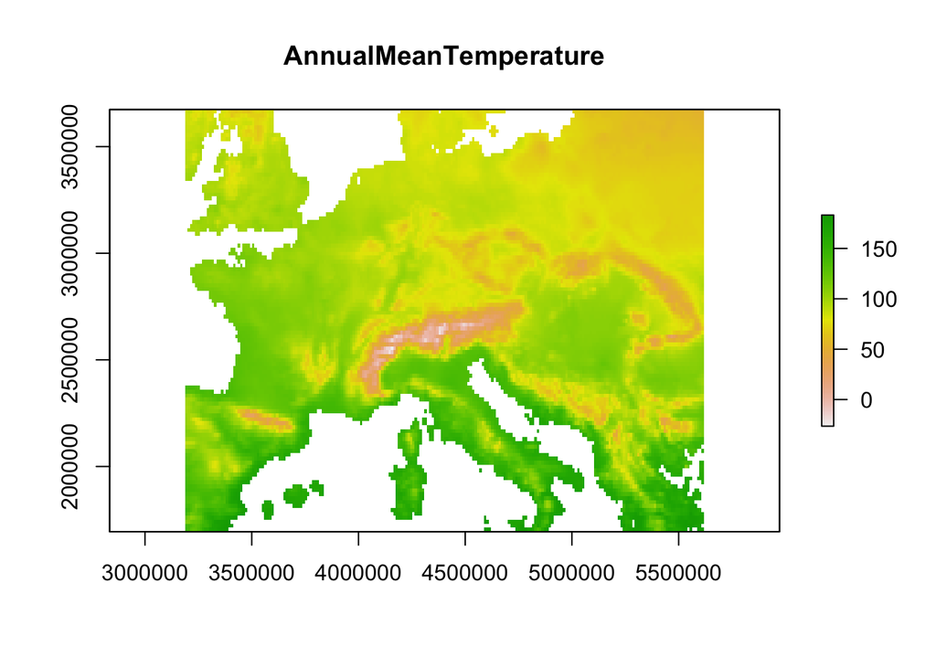

```r
# first we need harminize resolution and crop the climate data to have the same extent

clim <- crop(clim, abies_ras)
plot(clim, y = 1)
```

```r
# then we can stack
abies_stack <- raster::stack(clim, abies_ras)

# option 1
# not best practice but hard coded to sample 20% of total cells (ncell)
abies_sample <- sampleRandom(abies_stack, size = 23219*.2)

abies.df <- as.data.frame(abies_sample)
head(abies.df)
```

```
##   AnnualMeanTemperature MeanDiurnalRange Isothermality TemperatureSeasonality
## 1              61.66280         70.21442      29.05459               5961.330
## 2              84.69520         76.75563      28.81195               6532.966
## 3             129.04482         94.68684      40.94042               4954.597
## 4              54.31466         88.67152      30.00000               7222.714
## 5              97.84315         77.00000      33.36912               5624.465
## 6              80.69305         83.14542      30.00000               6701.385
##   MaxTemperatureofWarmestMonth MinTemperatureofColdestMonth
## 1                     189.9864                   -48.433739
## 2                     229.3039                   -32.325508
## 3                     254.1980                    23.869131
## 4                     204.3221                   -89.144623
## 5                     221.2291                    -4.663527
## 6                     231.3087                   -40.591850
##   TemperatureAnnualRange MeanTemperatureofWettestQuarter
```

[output cut: 48 more lines]

```r
# rename variables
names(abies.df) <- c("AnnualMeanTemperature", "MeanDiurnalRange", "Isothermality", "TemperatureSeasonality",
                 "MaxTemperatureofWarmestMonth", "MinTemperatureofColdestMonth", "TemperatureAnnualRange", "MeanTemperatureofWettestQuarter", "MeanTemperatureofDriestQuarter", "MeanTemperatureofWarmestQuarter", "MeanTemperatureofColdestQuarter", "AnnualPrecipitation", "PrecipitationofWettestMonth", "PrecipitationofDriestMonth", "PrecipitationSeasonality", "PrecipitationofWettestQuarter", "PrecipitationofDriestQuarter", "PrecipitationofWarmestQuarter", "PrecipitationofColdestQuarter", "Abies")

# option 2
abies.df <- as.data.frame(abies_stack)
abies_sample <- abies.df %>%
  dplyr::group_by(layer) %>%
  dplyr::sample_frac(layer, 20) %>%
  mutate(Abies = layer)
```

## 3) Build a model predicting the count of *Abies alba* (3 Points)

Use a GLM to predict the occurrence of *Abies alba* from bioclim data. You can hand-pick variables or use a variable selection technique. Your choice.

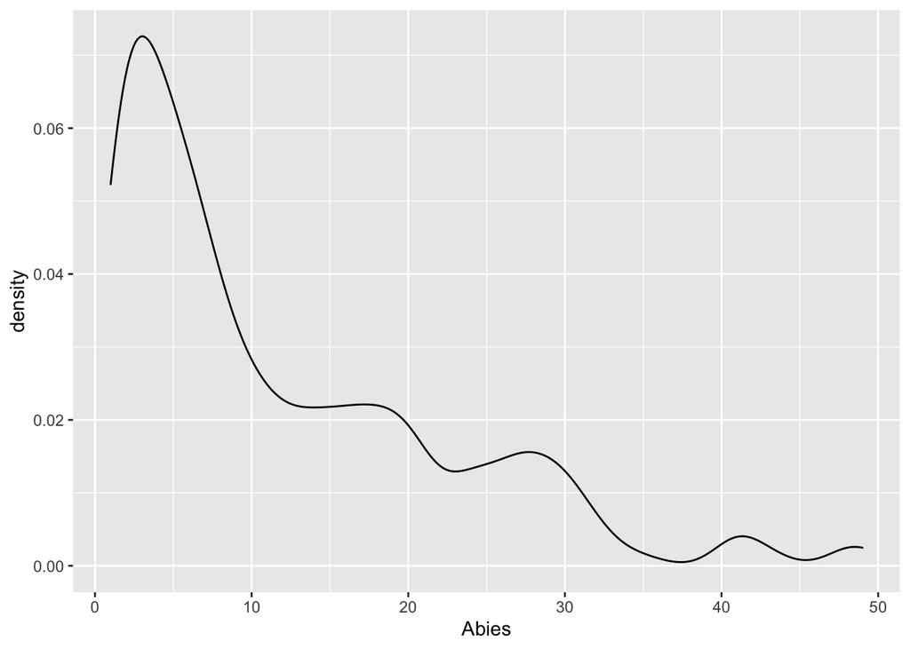

```r
ggplot(abies_sample, aes(x = Abies)) +
         geom_density()
```

```r
m1 <- glm(data = abies_sample, Abies ~ AnnualMeanTemperature + AnnualPrecipitation, family = "poisson")
summary(m1)
```

```
##
## Call:
## glm(formula = Abies ~ AnnualMeanTemperature + AnnualPrecipitation,
##     family = "poisson", data = abies_sample)
##
## Deviance Residuals:
##     Min       1Q   Median       3Q      Max
## -9.0552  -2.3404  -0.9209   1.3597   8.0745
##
## Coefficients:
##                         Estimate Std. Error z value Pr(>|z|)
## (Intercept)           -3.803e-01  2.922e-02  -13.01   <2e-16 ***
## AnnualMeanTemperature  1.446e-02  2.012e-04   71.88   <2e-16 ***
## AnnualPrecipitation    1.737e-03  1.712e-05  101.47   <2e-16 ***
## ---
## Signif. codes:  0 '***' 0.001 '**' 0.01 '*' 0.05 '.' 0.1 ' ' 1
##
## (Dispersion parameter for poisson family taken to be 1)
##
##     Null deviance: 80786  on 9372  degrees of freedom
## Residual deviance: 69456  on 9370  degrees of freedom
## AIC: 105831
##
## Number of Fisher Scoring iterations: 5
```

```r
# install.packages("MuMIn")
library(MuMIn)

# create semi-saturated model, with the broader variables based on my novice guess, I a priori think will be more relavent
m_saturated <- glm(data = abies_sample, Abies ~ AnnualMeanTemperature + Isothermality + TemperatureSeasonality + TemperatureAnnualRange + AnnualPrecipitation + PrecipitationSeasonality, family = "poisson")

summary(m_saturated)
```

```
##
## Call:
## glm(formula = Abies ~ AnnualMeanTemperature + Isothermality +
##     TemperatureSeasonality + TemperatureAnnualRange + AnnualPrecipitation +
##     PrecipitationSeasonality, family = "poisson", data = abies_sample)
##
## Deviance Residuals:
##     Min       1Q   Median       3Q      Max
## -7.3876  -1.8635  -0.4416   1.2485   7.1714
##
## Coefficients:
##                            Estimate Std. Error z value Pr(>|z|)
## (Intercept)              -5.487e+00  1.605e-01  -34.18   <2e-16 ***
## AnnualMeanTemperature     6.277e-03  2.579e-04   24.34   <2e-16 ***
## Isothermality             2.067e-01  3.652e-03   56.60   <2e-16 ***
## TemperatureSeasonality    2.961e-03  3.661e-05   80.87   <2e-16 ***
## TemperatureAnnualRange   -6.990e-02  8.368e-04  -83.53   <2e-16 ***
## AnnualPrecipitation       1.224e-03  2.510e-05   48.76   <2e-16 ***
## PrecipitationSeasonality -4.077e-02  4.903e-04  -83.15   <2e-16 ***
## ---
## Signif. codes:  0 '***' 0.001 '**' 0.01 '*' 0.05 '.' 0.1 ' ' 1
##
## (Dispersion parameter for poisson family taken to be 1)
##
##     Null deviance: 80786  on 9372  degrees of freedom
## Residual deviance: 53104  on 9366  degrees of freedom
## AIC: 89487
##
## Number of Fisher Scoring iterations: 5
```

```r
options(na.action = "na.fail") # Required for dredge to run

model_dredge <- dredge(m_saturated, beta = F, evaluate = T, rank = AICc)
```

```
## Fixed term is "(Intercept)"
```

```r
options(na.action = "na.omit") # set back to default

head(model_dredge)
```

```
## Global model call: glm(formula = Abies ~ AnnualMeanTemperature + Isothermality +
##     TemperatureSeasonality + TemperatureAnnualRange + AnnualPrecipitation +
##     PrecipitationSeasonality, family = "poisson", data = abies_sample)
## ---
## Model selection table
##     (Intrc)      AnnMT     AnnlP  Isthr    PrcpS    TmpAR    TmprS df    logLik
## 64 -5.48700  0.0062770 0.0012240 0.2067 -0.04077 -0.06990 0.002961  7 -44736.68
## 63 -5.02600            0.0008927 0.2212 -0.04400 -0.07211 0.003043  6 -45031.39
## 62 -0.18560 -0.0006141           0.1279 -0.05133 -0.05640 0.002276  6 -45910.40
## 61 -0.05732                      0.1231 -0.05126 -0.05564 0.002241  5 -45914.45
## 60  2.69400  0.0081190 0.0005672        -0.04458 -0.02953 0.001142  6 -46420.08
## 58  3.97200  0.0037480                  -0.04993 -0.03092 0.001157  5 -46736.29
##       AICc   delta weight
## 64 89487.4    0.00      1
## 63 90074.8  587.40      0
## 62 91832.8 2345.44      0
## 61 91838.9 2351.53      0
## 60 92852.2 3364.79      0
## 58 93482.6 3995.20      0
## Models ranked by AICc(x)
```

```r
nrow(model_dredge) # 64 models in total
```

```
## [1] 64
```

```r
top_model <- get.models(model_dredge, subset = 1)[[1]]
top_model
```

```
##
## Call:  glm(formula = Abies ~ AnnualMeanTemperature + AnnualPrecipitation +
##     Isothermality + PrecipitationSeasonality + TemperatureAnnualRange +
##     TemperatureSeasonality + 1, family = "poisson", data = abies_sample)
##
## Coefficients:
##              (Intercept)     AnnualMeanTemperature       AnnualPrecipitation
##                -5.487068                  0.006277                  0.001224
##            Isothermality  PrecipitationSeasonality    TemperatureAnnualRange
##                 0.206716                 -0.040769                 -0.069905
##   TemperatureSeasonality
##                 0.002961
##
## Degrees of Freedom: 9372 Total (i.e. Null);  9366 Residual
## Null Deviance:       80790
## Residual Deviance: 53100     AIC: 89490
```

```r
# Summarize top model
summary(top_model)
```

```
##
## Call:
## glm(formula = Abies ~ AnnualMeanTemperature + AnnualPrecipitation +
##     Isothermality + PrecipitationSeasonality + TemperatureAnnualRange +
##     TemperatureSeasonality + 1, family = "poisson", data = abies_sample)
##
## Deviance Residuals:
##     Min       1Q   Median       3Q      Max
## -7.3876  -1.8635  -0.4416   1.2485   7.1714
##
## Coefficients:
##                            Estimate Std. Error z value Pr(>|z|)
## (Intercept)              -5.487e+00  1.605e-01  -34.18   <2e-16 ***
## AnnualMeanTemperature     6.277e-03  2.579e-04   24.34   <2e-16 ***
## AnnualPrecipitation       1.224e-03  2.510e-05   48.76   <2e-16 ***
## Isothermality             2.067e-01  3.652e-03   56.60   <2e-16 ***
## PrecipitationSeasonality -4.077e-02  4.903e-04  -83.15   <2e-16 ***
## TemperatureAnnualRange   -6.990e-02  8.368e-04  -83.53   <2e-16 ***
## TemperatureSeasonality    2.961e-03  3.661e-05   80.87   <2e-16 ***
## ---
## Signif. codes:  0 '***' 0.001 '**' 0.01 '*' 0.05 '.' 0.1 ' ' 1
##
## (Dispersion parameter for poisson family taken to be 1)
##
##     Null deviance: 80786  on 9372  degrees of freedom
## Residual deviance: 53104  on 9366  degrees of freedom
## AIC: 89487
##
## Number of Fisher Scoring iterations: 5
```

```r
# psudo R^2
1- summary(top_model)$deviance / summary(top_model)$null.deviance
```

```
## [1] 0.342662
```

## 4) Create a map of the predicted *Abies alba* counts (2 Point)

```r
library(gridExtra)

#predict to a raster
abies_predited <- predict(abies_stack, top_model, progress='text')
```

```r
# comparing orginal and predicted map
mapview(abies_ras)
```

[interactive chart not shown]

```r
mapview(abies_predited)
```

[interactive chart not shown]